# A01_BAS_comparison

After fitting our feature selection horseshoe prior-based model, we’d like to compare it with BAS model in order to verify if the two methods agree on which covariates are more useful in explaining the target variable.

## 0. Dataset load

```r
train <- read.csv("../data/airline_train_n1200.csv", stringsAsFactors = FALSE)
train$y <- as.integer(train$satisfaction == "satisfied")

std <- function(x) as.numeric(scale(x))

service_items <- c("seat_comfort", "time_convenient", "food_drink", "gate_location", "wifi", "entertainment", "online_support", "ease_booking", "onboard_service","legroom", "baggage", "checkin", "cleanliness", "online_boarding" )
X_service <- apply(train[, service_items], 2, std)

logdep_std      <- std(train$log_dep_delay)
Age_std         <- std(train$age)
FlightDist_std  <- std(train$flight_distance)
logmid_delay    <- std(train$log_mid_delay)

Class_EcoPlus  <- as.integer(train$class == "Eco Plus")
Class_Business <- as.integer(train$class == "Business")
TypeTravel_Personal <- as.integer(train$travel_type == "Personal Travel")
CustType_disloyal   <- as.integer(train$customer_type == "disloyal Customer")

X_extra <- cbind(Age_std, FlightDist_std, Class_EcoPlus, Class_Business,
                 logdep_std, TypeTravel_Personal, CustType_disloyal, logmid_delay)
X_full <- cbind(X_service, X_extra)

df_bas <- data.frame(y = train$y, X_full)
```

# 1. `bas.glm` fit with a binomial family

```r
set.seed(123)
fit_glm_g <- bas.glm(y ~ ., data = df_bas, family = binomial(),
                      betaprior = g.prior(nrow(df_bas)), modelprior = uniform(),
                      method = "MCMC", MCMC.iterations = 100000)
```

```r
knitr::kable(round(summary(fit_glm_g, n.models = 5), 3),
                          caption = "Top 5 models by posterior probability (g-prior)")
```

Top 5 models by posterior probability (g-prior)

|  | P(B != 0 \| Y) | model 1 | model 2 | model 3 | model 4 | model 5 |
| --- | --- | --- | --- | --- | --- | --- |
| Intercept | 1.000 | 1.000 | 1.000 | 1.000 | 1.000 | 1.000 |
| seat_comfort | 0.834 | 1.000 | 1.000 | 1.000 | 1.000 | 0.000 |
| time_convenient | 0.970 | 1.000 | 1.000 | 1.000 | 1.000 | 1.000 |
| food_drink | 0.536 | 1.000 | 0.000 | 1.000 | 0.000 | 0.000 |
| gate_location | 0.038 | 0.000 | 0.000 | 0.000 | 0.000 | 0.000 |
| wifi | 0.050 | 0.000 | 0.000 | 0.000 | 0.000 | 0.000 |
| entertainment | 1.000 | 1.000 | 1.000 | 1.000 | 1.000 | 1.000 |
| online_support | 0.232 | 0.000 | 0.000 | 0.000 | 0.000 | 0.000 |
| ease_booking | 0.951 | 1.000 | 1.000 | 1.000 | 1.000 | 1.000 |
| onboard_service | 0.996 | 1.000 | 1.000 | 1.000 | 1.000 | 1.000 |
| legroom | 0.958 | 1.000 | 1.000 | 1.000 | 1.000 | 1.000 |
| baggage | 0.061 | 0.000 | 0.000 | 0.000 | 0.000 | 0.000 |
| checkin | 0.985 | 1.000 | 1.000 | 1.000 | 1.000 | 1.000 |
| cleanliness | 0.305 | 0.000 | 0.000 | 0.000 | 0.000 | 0.000 |
| online_boarding | 0.030 | 0.000 | 0.000 | 0.000 | 0.000 | 0.000 |
| Age_std | 0.035 | 0.000 | 0.000 | 0.000 | 0.000 | 0.000 |
| FlightDist_std | 0.037 | 0.000 | 0.000 | 0.000 | 0.000 | 0.000 |
| Class_EcoPlus | 0.030 | 0.000 | 0.000 | 0.000 | 0.000 | 0.000 |
| Class_Business | 0.994 | 1.000 | 1.000 | 1.000 | 1.000 | 1.000 |
| logdep_std | 0.085 | 0.000 | 0.000 | 0.000 | 0.000 | 0.000 |
| TypeTravel_Personal | 0.439 | 0.000 | 0.000 | 1.000 | 1.000 | 1.000 |
| CustType_disloyal | 1.000 | 1.000 | 1.000 | 1.000 | 1.000 | 1.000 |
| logmid_delay | 0.033 | 0.000 | 0.000 | 0.000 | 0.000 | 0.000 |
| BF | NA | 1.000 | 0.574 | 0.477 | 0.369 | 0.268 |
| PostProbs | NA | 0.136 | 0.070 | 0.066 | 0.047 | 0.029 |
| R2 | NA | 0.426 | 0.421 | 0.430 | 0.425 | 0.420 |
| dim | NA | 11.000 | 10.000 | 12.000 | 11.000 | 10.000 |
| logmarg | NA | -516.838 | -517.392 | -517.578 | -517.835 | -518.155 |

# 2. Parameter space convergence

Now we test the goodness of the MCMC search in the parameter space executed by BAS.

### Convergence within one run.

BAS reports two independent estimates of each posterior inclusion probability:

- `probne0.RB` : takes the set of distinct model visited containing the variable $j$, use their marginal likelihoods, renomalizes and sum the mass of those models
- `probne0.MCM`: it’s just the raw fraction of iterations the chain spent in some model containing variable $j$ If the chain has converged, they should agree closely.

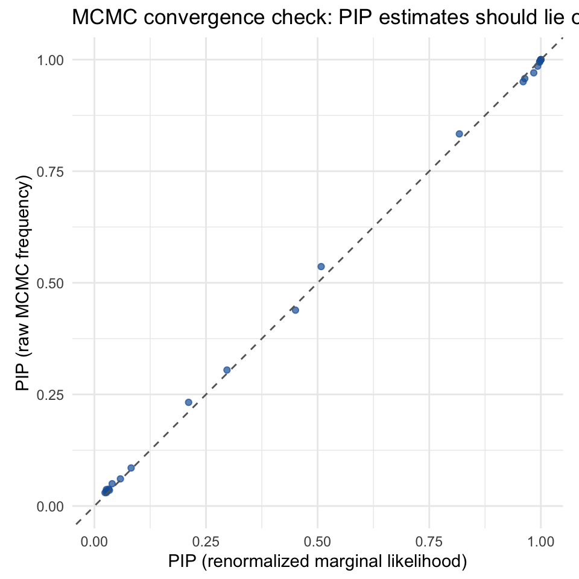

```r
diag_df <- data.frame(renormalized = fit_glm_g$probne0.RN,
                       mcmc = fit_glm_g$probne0.MCMC)
ggplot(diag_df, aes(renormalized, mcmc)) +
  geom_point(color = "#185FA5", alpha = 0.7) +
  geom_abline(slope = 1, intercept = 0, linetype = "dashed", color = "grey40") +
  coord_equal(xlim = c(0,1), ylim = c(0,1)) +
  labs(title = "MCMC convergence check: PIP estimates should lie on the diagonal",
       x = "PIP (renormalized marginal likelihood)", y = "PIP (raw MCMC frequency)") +
  theme_minimal(base_size = 11)
```

Correlation between the two estimates is 0.9998, maximum absolute difference 0.028 – the points sit essentially on the diagonal, the sign this run has converged.

### stability across seeds

We refit the identical model twice more with different random seeds and compare posterior inclusion probabilities (PIP) to check whether they agree or not.

```r
run_seed <- function(seed) {
  set.seed(seed)
  fit <- bas.glm(y ~ ., data = df_bas, family = binomial(),
                 betaprior = g.prior(nrow(df_bas)), modelprior = uniform(),
                 method = "MCMC", MCMC.iterations = 100000)
  fit$probne0
}
pip_seed1 <- run_seed(1)
pip_seed2 <- run_seed(2)

pip_df <- data.frame(term = fit_glm_g$namesx,
                      seed123 = fit_glm_g$probne0,
                      seed1 = pip_seed1, seed2 = pip_seed2)
pip_df$range <- apply(pip_df[, 2:4], 1, function(x) max(x) - min(x))
```

```r
knitr::kable(pip_df %>% arrange(desc(range)) %>% head(8), row.names = FALSE, digits = 3,
             caption = "Largest PIP swings across 3 seeds (of 22 predictors)")
```

Largest PIP swings across 3 seeds (of 22 predictors)

[output not shown]

```r
cat(sprintf("Max PIP range across seeds: %.3f\nMean PIP range across seeds: %.4f\n",
            max(pip_df$range), mean(pip_df$range)))
```

```
## Max PIP range across seeds: 0.021
## Mean PIP range across seeds: 0.0083
```

### BIC prior as a robustness check

We try another prior on the beta coefficients since, if the search is stable, the effect of the prior should vanish if the number of iterations is high enough.

```r
set.seed(123)
fit_glm_bic <- bas.glm(y ~ ., data = df_bas, family = binomial(),
                        betaprior = bic.prior(nrow(df_bas)), modelprior = uniform(),
                        method = "MCMC", MCMC.iterations = 100000)

cmp_prior <- data.frame(term = fit_glm_g$namesx, g_prior = round(fit_glm_g$probne0, 3),
                         BIC = round(fit_glm_bic$probne0, 3))
cmp_prior$abs_diff <- round(abs(cmp_prior$g_prior - cmp_prior$BIC), 3)
```

```r
knitr::kable(cmp_prior %>% arrange(desc(abs_diff)) %>% head(6), row.names = FALSE,
             caption = "Largest g-prior vs. BIC-prior PIP differences")
```

Largest g-prior vs. BIC-prior PIP differences

[output not shown]

```r
cat("Max |g-prior - BIC| difference:", max(cmp_prior$abs_diff), "\n")
```

```
## Max |g-prior - BIC| difference: 0.006
```

With 100,000 MCMC iterations, PIPs move by at most 0.021 across three different seeds and by at most 0.006 between the g-prior and the BIC-based prior. Given the number of MCMC iterations, the search prove itself to be stable.

# 3. BAS vs Horseshoe: model comparison

Finally we compare the models selected by the two approaches, check on which coefficient do they agree and on which they dont’.

```r
hs <- readRDS("../data/03_horseshoe_summary.rds")
hs_names_raw <- c("seat_confort", "time_convenience", "food_drink",
                   "gate_location", "wifi", "entertainment",
                   "online_support", "ease_booking", "onboard_service",
                   "legroom", "baggage", "checkin",
                   "cleanliness", "online_boarding", "Age_std", "FlightDist_std",
                   "Class_EcoPlus", "Class_Business", "logdep_std",
                   "TypeTravel_Personal", "CustType_disloyal", "logmid_delay")
kappa_ordered <- hs$post_kappa[c(paste0("beta[", 1:21, "]"), "beta_arr")]

names(kappa_ordered)
```

```
##  [1] "beta[1]"  "beta[2]"  "beta[3]"  "beta[4]"  "beta[5]"  "beta[6]"
##  [7] "beta[7]"  "beta[8]"  "beta[9]"  "beta[10]" "beta[11]" "beta[12]"
## [13] "beta[13]" "beta[14]" "beta[15]" "beta[16]" "beta[17]" "beta[18]"
## [19] "beta[19]" "beta[20]" "beta[21]" "beta_arr"
```

```r
length(hs$post_kappa)
```

```
## [1] 22
```

```r
cmp_methods <- data.frame(term = hs_names_raw,
                           PIP = round(fit_glm_g$probne0[-1], 3),
                           kappa = round(kappa_ordered, 3))
cmp_methods$signal_BAS <- cmp_methods$PIP > 0.5
cmp_methods$signal_HS  <- cmp_methods$kappa < 0.5
cmp_methods$agree <- cmp_methods$signal_BAS == cmp_methods$signal_HS
cmp_methods %>% filter(!agree)
```

```
##                         term   PIP kappa signal_BAS signal_HS agree
## beta[20] TypeTravel_Personal 0.439 0.351      FALSE      TRUE FALSE
```

```r
agreement_rate <- mean(cmp_methods$agree)
print("two methods agreement rate is: ")
```

```
## [1] "two methods agreement rate is: "
```

```r
agreement_rate
```

```
## [1] 0.9545455
```

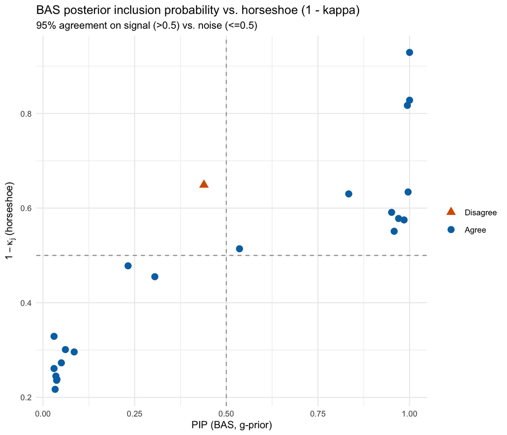

```r
cmp_methods %>%
  mutate(term = factor(term, levels = term[order(PIP)])) %>%
  ggplot(aes(x = PIP, y = 1 - kappa, color = agree, shape = agree)) +
  geom_point(size = 3) +
  geom_hline(yintercept = 0.5, linetype = "dashed", color = "grey60") +
  geom_vline(xintercept = 0.5, linetype = "dashed", color = "grey60") +
  scale_color_manual(values = c("TRUE" = "#0072B2", "FALSE" = "#D55E00"),
                      labels = c("TRUE" = "Agree", "FALSE" = "Disagree"), name = NULL) +
  scale_shape_manual(values = c("TRUE" = 16, "FALSE" = 17),
                      labels = c("TRUE" = "Agree", "FALSE" = "Disagree"), name = NULL) +
  labs(title = "BAS posterior inclusion probability vs. horseshoe (1 - kappa)",
       subtitle = sprintf("%.0f%% agreement on signal (>0.5) vs. noise (<=0.5)", 100*agreement_rate),
       x = "PIP (BAS, g-prior)", y = expression(1 - kappa[j]~"(horseshoe)")) +
  theme_minimal(base_size = 10)
```

## 4.Export results

```r
saveRDS(fit_glm_g, "../data/A01_BAS_model.rds")
```